# IBM Attriration-Kaggle

sidharth Khatua

30 April 2018

# Description of the Dataset

Link to the website :- https://www.kaggle.com/pavansubhasht/ibm-hr-analytics-attrition-dataset

Uncover the factors that lead to employee attrition and explore important questions such as ‘show me a breakdown of distance from home by job role and attrition’ or ‘compare average monthly income by education and attrition’. This is a fictional data set created by IBM data scientists.

Education 1 ‘Below College’ 2 ‘College’ 3 ‘Bachelor’ 4 ‘Master’ 5 ‘Doctor’

EnvironmentSatisfaction 1 ‘Low’ 2 ‘Medium’ 3 ‘High’ 4 ‘Very High’

JobInvolvement 1 ‘Low’ 2 ‘Medium’ 3 ‘High’ 4 ‘Very High’

JobSatisfaction 1 ‘Low’ 2 ‘Medium’ 3 ‘High’ 4 ‘Very High’

PerformanceRating 1 ‘Low’ 2 ‘Good’ 3 ‘Excellent’ 4 ‘Outstanding’

RelationshipSatisfaction 1 ‘Low’ 2 ‘Medium’ 3 ‘High’ 4 ‘Very High’

WorkLifeBalance 1 ‘Bad’ 2 ‘Good’ 3 ‘Better’ 4 ‘Best’

## Import library

```r
library(tidyverse)
library(caret)
library(rpart)
library(rattle)
library(Amelia)
library(plotly)
library(gridExtra)
library(VIM)
library(ROCR)
library(randomForest)
```

## Import the dataset

```r
ibm <- read.csv('IBM.csv',stringsAsFactors = TRUE,na.strings = c(' ','',NA))
str(ibm)
```

```
## 'data.frame':    1470 obs. of  35 variables:
##  $ ï..Age                  : int  41 49 37 33 27 32 59 30 38 36 ...
##  $ Attrition               : Factor w/ 2 levels "No","Yes": 2 1 2 1 1 1 1 1 1 1 ...
##  $ BusinessTravel          : Factor w/ 3 levels "Non-Travel","Travel_Frequently",..: 3 2 3 2 3 2 3 3 2 3 ...
##  $ DailyRate               : int  1102 279 1373 1392 591 1005 1324 1358 216 1299 ...
##  $ Department              : Factor w/ 3 levels "Human Resources",..: 3 2 2 2 2 2 2 2 2 2 ...
##  $ DistanceFromHome        : int  1 8 2 3 2 2 3 24 23 27 ...
##  $ Education               : int  2 1 2 4 1 2 3 1 3 3 ...
##  $ EducationField          : Factor w/ 6 levels "Human Resources",..: 2 2 5 2 4 2 4 2 2 4 ...
##  $ EmployeeCount           : int  1 1 1 1 1 1 1 1 1 1 ...
##  $ EmployeeNumber          : int  1 2 4 5 7 8 10 11 12 13 ...
##  $ EnvironmentSatisfaction : int  2 3 4 4 1 4 3 4 4 3 ...
##  $ Gender                  : Factor w/ 2 levels "Female","Male": 1 2 2 1 2 2 1 2 2 2 ...
##  $ HourlyRate              : int  94 61 92 56 40 79 81 67 44 94 ...
##  $ JobInvolvement          : int  3 2 2 3 3 3 4 3 2 3 ...
```

[output cut: 21 more lines]

## Check for missing variables

we use **missmap()** to visualise the missingness in the data.

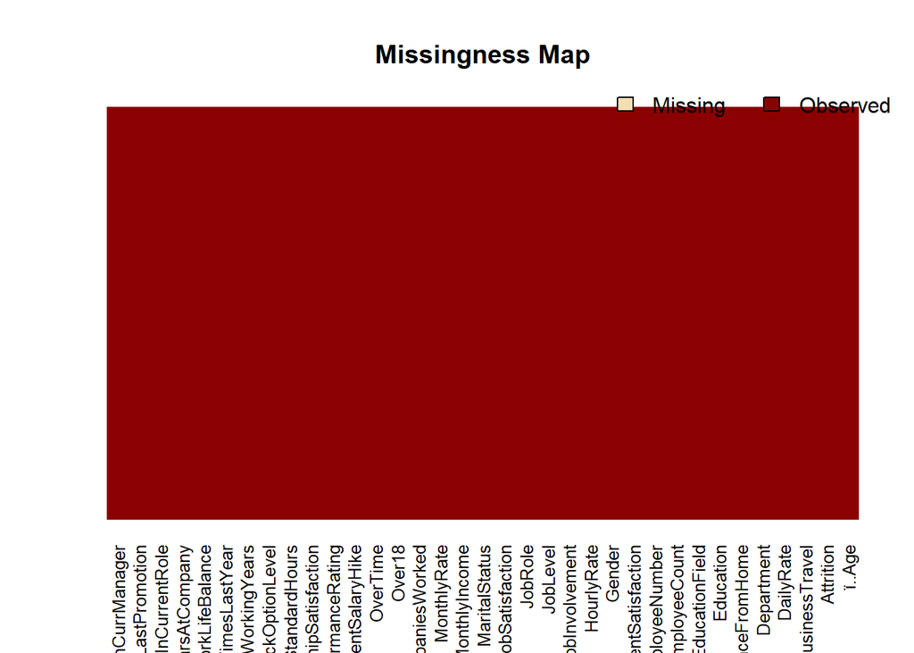

```r
missmap(ibm,y.at = c(1),y.labels = c(''))
```

Above chart indicates that there is no missingness in the data.

## EDA analysis on the dataset.

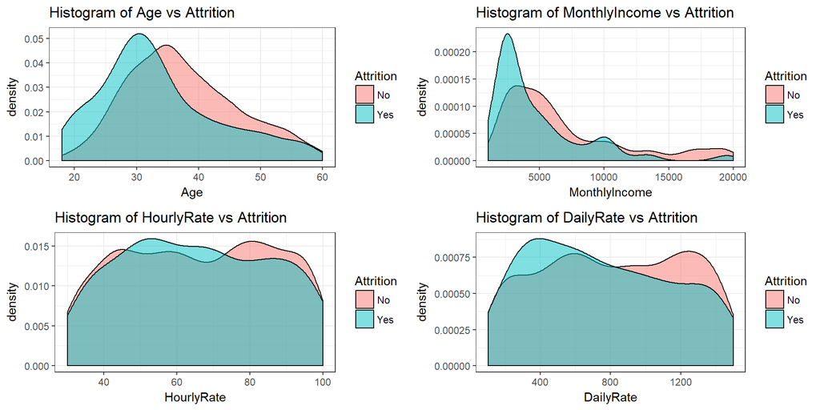

```r
a <-ggplot(ibm,aes(ï..Age,fill=Attrition))+
  geom_density(color='black',alpha=.5)+
  ggtitle('Histogram of Age vs Attrition')+
  theme_bw()+
  xlab('Age')
b <- ggplot(ibm,aes(MonthlyIncome,fill=Attrition))+
  geom_density(color='black',alpha=.5)+
  ggtitle('Histogram of MonthlyIncome vs Attrition')+
  theme_bw()+
  xlab('MonthlyIncome')
c <- ggplot(ibm,aes(HourlyRate,fill=Attrition))+
  geom_density(color='black',alpha=.5)+
  ggtitle('Histogram of HourlyRate vs Attrition')+
  theme_bw()+
  xlab('HourlyRate')
d <- ggplot(ibm,aes(DailyRate,fill=Attrition))+
  geom_density(color='black',alpha=.5)+
  ggtitle('Histogram of DailyRate vs Attrition')+
  theme_bw()+
  xlab('DailyRate')
grid.arrange(a,b,c,d)
```

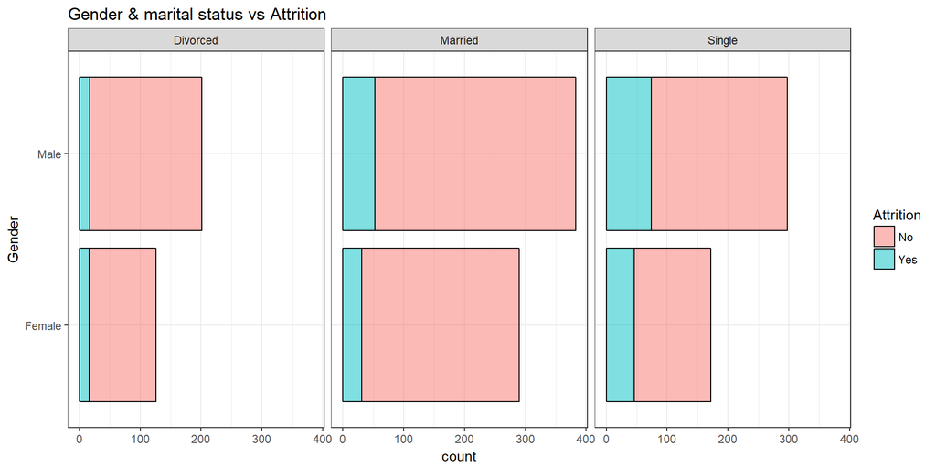

```r
e <-ggplot(ibm,aes(ibm$JobRole,fill=Attrition))+
  geom_bar(color='black',alpha=.5)+
  ggtitle('JobRole vs Attrition')+
  theme_bw()+
  xlab('jobrole')+
  coord_flip()

f <- ggplot(ibm,aes(ibm$EducationField,fill=Attrition))+
  geom_bar(color='black',alpha=.5)+
  ggtitle('Education Field vs Attrition')+
  theme_bw()+
  xlab('jobrole')+
  coord_flip()

g <-ggplot(ibm,aes(ibm$NumCompaniesWorked,fill=Attrition))+
  geom_histogram(color='black',alpha=.5)+
  ggtitle('No of Companies Worked vs Attrition')+
  theme_bw()+
  xlab('No of Companies Worked')+
  scale_x_continuous(breaks = seq(0,15,1))

h <-ggplot(ibm,aes(ibm$WorkLifeBalance,fill=Attrition))+
  geom_bar(color='black',alpha=.5)+
  ggtitle('Worklifebalance vs Attrition')+
  theme_bw()+
  xlab('Worklifebalance')+
  coord_flip()

i <- ggplot(ibm,aes(ibm$Gender,fill=Attrition))+
  geom_bar(color='black',alpha=.5)+
  ggtitle('Gender & marital status vs Attrition')+
  theme_bw()+
  xlab('Gender')+
  coord_flip()+facet_wrap(~MaritalStatus)
i
```

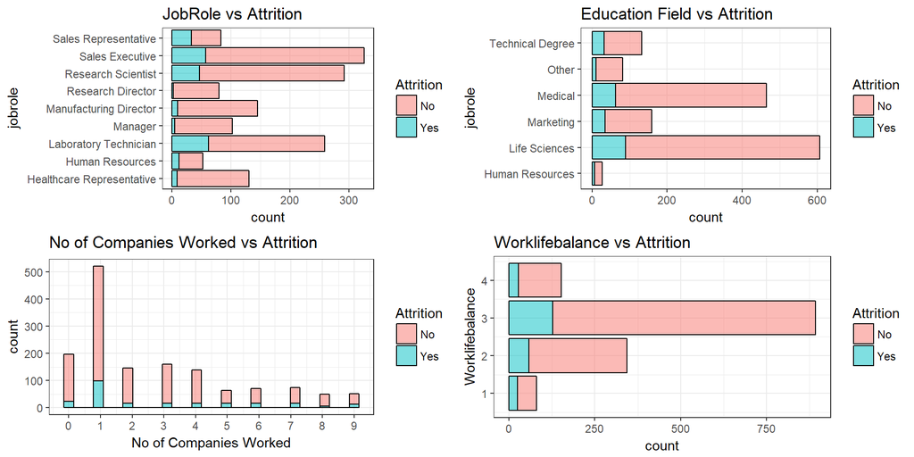

```r
grid.arrange(e,f,g,h)
```

From the above Diagram we can observe that:

1. Single Male churn higher compared to others.
2. Lab tech, Sales executives, Research scientist churn higher compared to others.
3. Employee with life sciences and Medical tend to churn higher.
4. Employee with 1 company worked with before tend to churn higher.
5. Employee with better work life balance churn high compared to others.

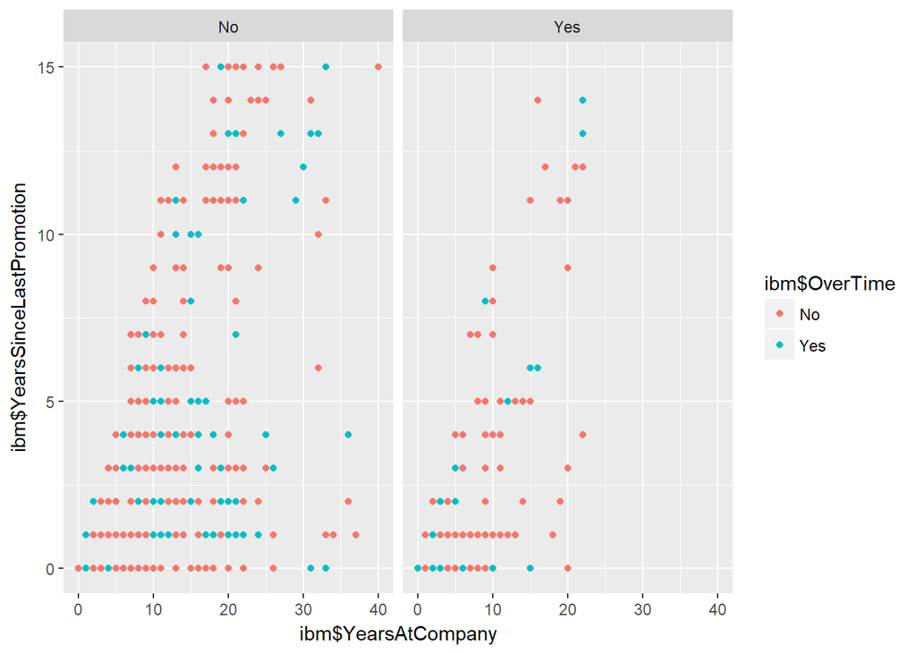

```r
ggplot(ibm,aes(ibm$YearsAtCompany,ibm$YearsSinceLastPromotion,color=ibm$OverTime))+
  geom_point()+
  facet_wrap(~ibm$Attrition)
```

From the above Diagram we can observe that:

1. The longer you stay in the company the longer is the years since last promotion.

## Data spliting.

we will split the data into two set **train** and **test** set of ratio **70:30**.

we will train the model on **train** set and validate the model on **test** set.

```r
sample <- createDataPartition(ibm$Attrition,times = 1,p = .7,list = FALSE)
ibm.train <- ibm[sample,]
ibm.test <- ibm[-sample,]
```

## Model Used: [Decision Tree](https://www.analyticsvidhya.com/blog/2016/04/complete-tutorial-tree-based-modeling-scratch-in-python/)

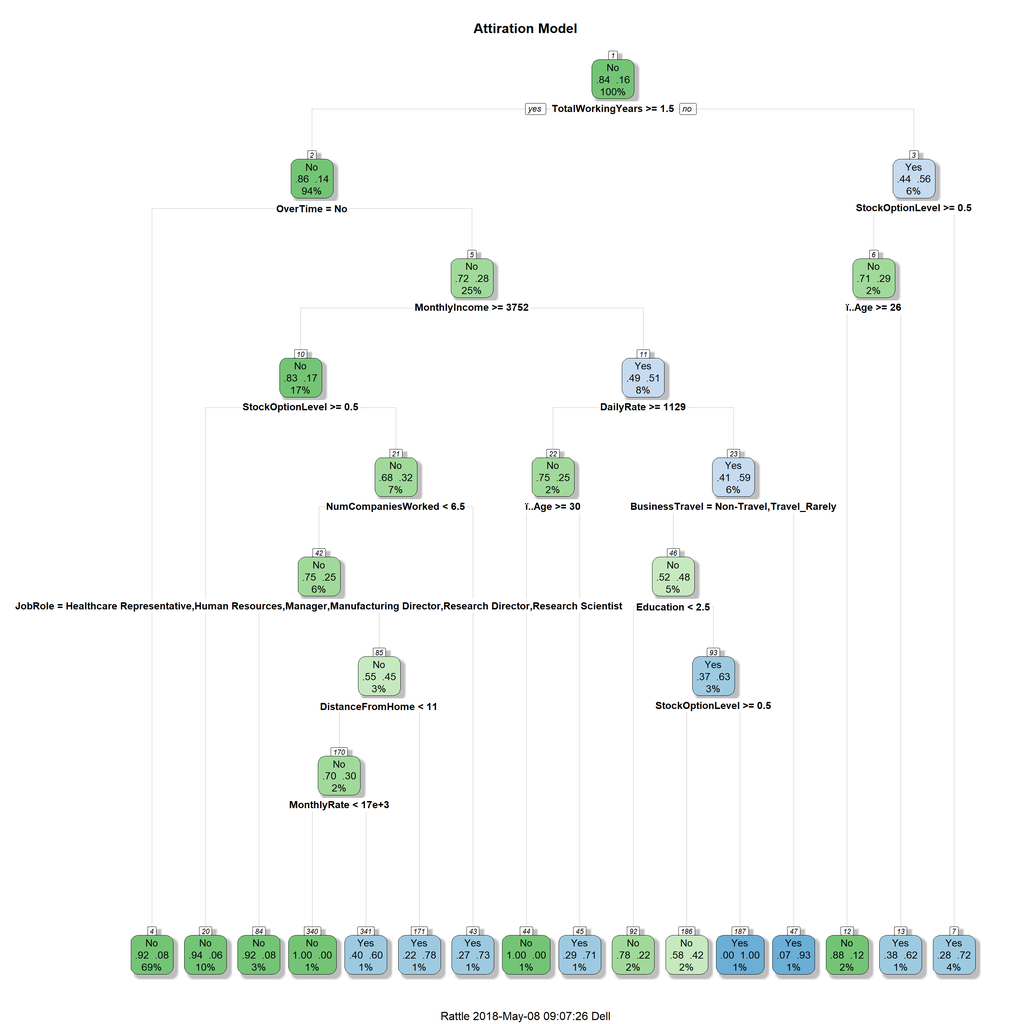

```r
set.seed(100)
model.rpart <- rpart(Attrition~.,data = ibm.train)
fancyRpartPlot(model.rpart,main = 'Attiration Model',type =2)
```

```r
predict.y <- predict(model.rpart,newdata = ibm.test[,-2],type = 'class')
#Validation
confusionMatrix(ibm.test$Attrition,predict.y)
```

```
## Confusion Matrix and Statistics
##
##           Reference
## Prediction  No Yes
##        No  342  27
##        Yes  50  21
##
##                Accuracy : 0.825
##                  95% CI : (0.7862, 0.8594)
##     No Information Rate : 0.8909
##     P-Value [Acc > NIR] : 0.99999
##
##                   Kappa : 0.2561
##  Mcnemar's Test P-Value : 0.01217
##
##             Sensitivity : 0.8724
##             Specificity : 0.4375
##          Pos Pred Value : 0.9268
##          Neg Pred Value : 0.2958
##              Prevalence : 0.8909
##          Detection Rate : 0.7773
##    Detection Prevalence : 0.8386
##       Balanced Accuracy : 0.6550
##
##        'Positive' Class : No
##
```

1:We have tried **Pruning the model** to simplify the model.

2:Used **plotcp()** to get the graph where we can establish the **CP compelixity parameter.**

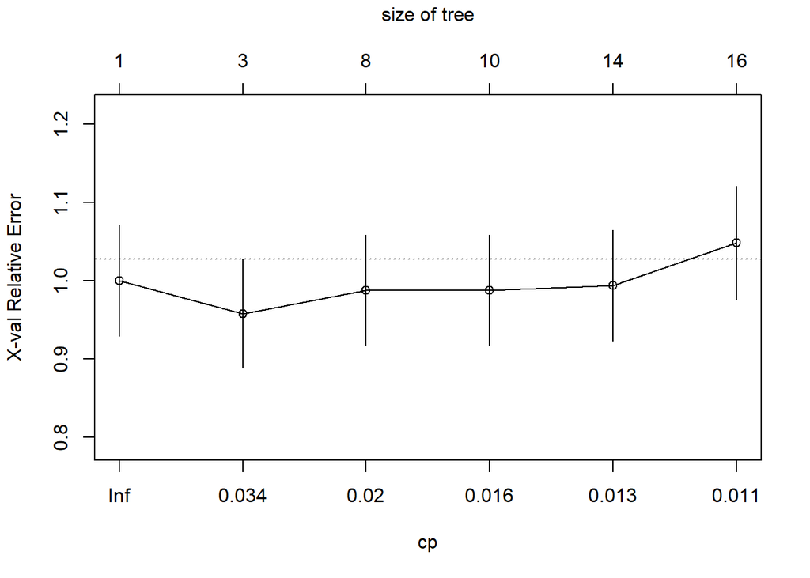

```r
##pruning the data:
plotcp(model.rpart,minline = TRUE)
```

[figure not shown]

```r
model.rpart.prune <- prune(model.rpart,cp = .038)

##Visulalize Prune Descision Tree
fancyRpartPlot(model.rpart.prune,main = "Attiration Model")
```

```r
predict.prune <- predict(model.rpart.prune,type = 'class',newdata = ibm.test[,-2])

#Validation using confusion matrix.
confusionMatrix(ibm.test$Attrition,predict.prune)
```

```
## Confusion Matrix and Statistics
##
##           Reference
## Prediction  No Yes
##        No  359  10
##        Yes  66   5
##
##                Accuracy : 0.8273
##                  95% CI : (0.7886, 0.8614)
##     No Information Rate : 0.9659
##     P-Value [Acc > NIR] : 1
##
##                   Kappa : 0.0636
##  Mcnemar's Test P-Value : 2.81e-10
##
##             Sensitivity : 0.84471
##             Specificity : 0.33333
##          Pos Pred Value : 0.97290
##          Neg Pred Value : 0.07042
##              Prevalence : 0.96591
##          Detection Rate : 0.81591
##    Detection Prevalence : 0.83864
##       Balanced Accuracy : 0.58902
##
##        'Positive' Class : No
##
```

## Model Used: [Random Forest](https://www.analyticsvidhya.com/blog/2014/06/introduction-random-forest-simplified/)

```r
set.seed(101)
model.rf <- randomForest(Attrition~.,data = ibm.train)

predict.rf <- predict(model.rf,newdata = ibm.test[,-2])

#validate
confusionMatrix(predict.rf,ibm.test$Attrition)
```

```
## Confusion Matrix and Statistics
##
##           Reference
## Prediction  No Yes
##        No  365  58
##        Yes   4  13
##
##                Accuracy : 0.8591
##                  95% CI : (0.823, 0.8902)
##     No Information Rate : 0.8386
##     P-Value [Acc > NIR] : 0.1345
##
##                   Kappa : 0.2486
##  Mcnemar's Test P-Value : 1.685e-11
##
##             Sensitivity : 0.9892
##             Specificity : 0.1831
##          Pos Pred Value : 0.8629
##          Neg Pred Value : 0.7647
##              Prevalence : 0.8386
##          Detection Rate : 0.8295
##    Detection Prevalence : 0.9614
##       Balanced Accuracy : 0.5861
##
##        'Positive' Class : No
##
```

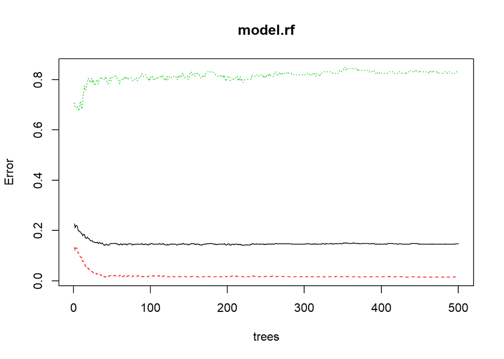

```r
#Plot the Error Metric
plot(model.rf)
```

## Important variables related to Atrriration rate.

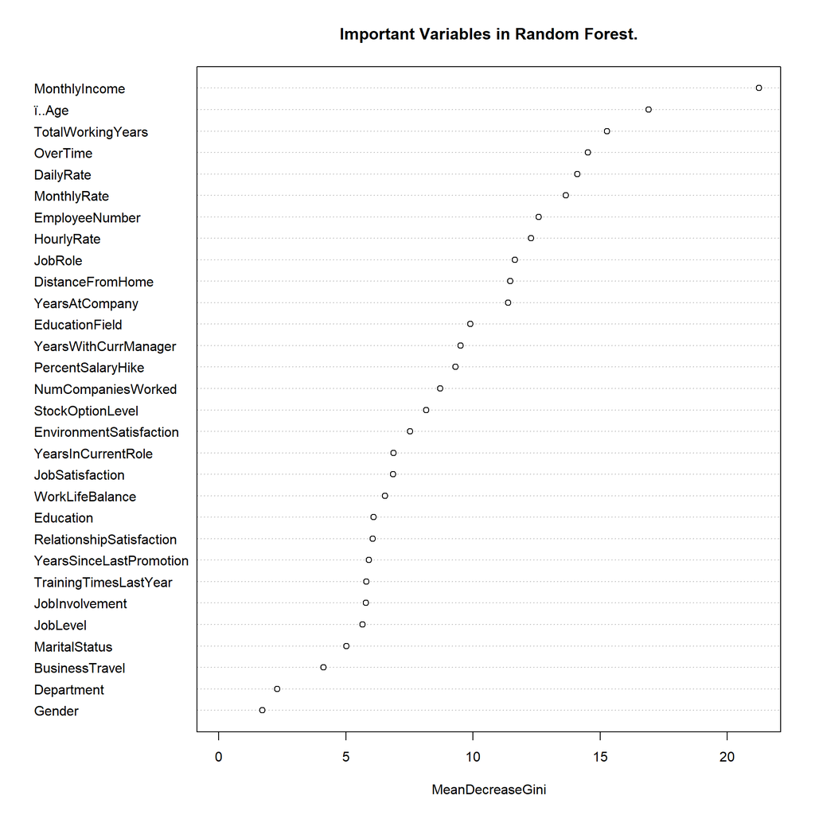

```r
varImpPlot(model.rf,main = 'Important Variables in Random Forest.')
```